# Solução Airbnb Rio

```python
import pandas as pd    # trabalhar com dados
import pathlib      # percorrer toda uma pasta
import numpy as np    # tratamento de numero, series, variaveis
import seaborn as sns   # biblioteca de graficos
import matplotlib.pyplot as plt    # biblioteca de graficos
import plotly.express as px
from sklearn.metrics import r2_score, mean_squared_error
from sklearn.linear_model import LinearRegression
from sklearn.ensemble import RandomForestRegressor, ExtraTreesRegressor
from sklearn.model_selection import train_test_split

print("PRONTO")
```

```
PRONTO
```

### Importar Bibliotecas e Bases de Dados

```python
meses = {'jan': 1, 'fev':2, 'mar':3, 'abr': 4, 'mai':5, 'jun': 6, 'jul': 7, 'ago': 8, 'set': 9, 'out': 10, 'nov': 11, 'dez': 12}

caminho_bases = pathlib.Path(r'C:\Users\Samsung\Desktop\TREINAMENTO\python\projetoAirbnb\dataset')

base_airbnb = pd.DataFrame()

for arquivo in caminho_bases.iterdir():
    nome_mes = arquivo.name[:3]
    mes = meses[nome_mes]

    ano = arquivo.name[-8:]
    ano = int(ano.replace('.csv', ''))

    df = pd.read_csv(caminho_bases / arquivo.name, low_memory=False)
    df['ano'] = ano
    df['mes'] = mes
    base_airbnb = pd.concat([df, base_airbnb])
```

```python
# visualizar dados
base_d_dados = base_airbnb
display(base_d_dados)
```

|  | id | listing_url | scrape_id | last_scraped | name | summary | space | description | experiences_offered | neighborhood_overview | ... | cancellation_policy | require_guest_profile_picture | require_guest_phone_verification | calculated_host_listings_count | calculated_host_listings_count_entire_homes | calculated_host_listings_count_private_rooms | calculated_host_listings_count_shared_rooms | reviews_per_month | ano | mes |
| --- | --- | --- | --- | --- | --- | --- | --- | --- | --- | --- | --- | --- | --- | --- | --- | --- | --- | --- | --- | --- | --- |
| 0 | 17878 | https://www.airbnb.com/rooms/17878 | 20190923212307 | 2019-09-24 | Very Nice 2Br - Copacabana - WiFi | Please note that special rates apply for Carni... | - large balcony which looks out on pedestrian ... | Please note that special rates apply for Carni... | none | This is the best spot in Rio. Everything happe... | ... | strict_14_with_grace_period | f | f | 1 | 1.0 | 0.0 | 0.0 | 2.13 | 2019 | 9 |
| 1 | 25026 | https://www.airbnb.com/rooms/25026 | 20190923212307 | 2019-09-24 | Beautiful Modern Decorated Studio in Copa | Our apartment is a little gem, everyone loves ... | This newly renovated studio (last renovations ... | Our apartment is a little gem, everyone loves ... | none | Copacabana is a lively neighborhood and the ap... | ... | strict_14_with_grace_period | t | t | 3 | 3.0 | 0.0 | 0.0 | 2.06 | 2019 | 9 |
| 2 | 31560 | https://www.airbnb.com/rooms/31560 | 20190923212307 | 2019-09-24 | NICE & COZY 1BDR - IPANEMA BEACH | This nice and clean 1 bedroom apartment is loc... | This nice and clean 1 bedroom apartment is loc... | This nice and clean 1 bedroom apartment is loc... | none | Die Nachbarschaft von Ipanema ist super lebend... | ... | strict_14_with_grace_period | f | f | 1 | 1.0 | 0.0 | 0.0 | 2.36 | 2019 | 9 |
| 3 | 35636 | https://www.airbnb.com/rooms/35636 | 20190923212307 | 2019-09-24 | Cosy flat close to Ipanema beach | This cosy apartment is just a few steps away ... | The location is extremely convenient, safe and... | This cosy apartment is just a few steps away ... | none | The apartment street is very quiet and safe .... | ... | strict_14_with_grace_period | t | t | 1 | 1.0 | 0.0 | 0.0 | 2.25 | 2019 | 9 |
| 4 | 35764 | https://www.airbnb.com/rooms/35764 | 20190923212307 | 2019-09-24 | COPACABANA SEA BREEZE - RIO - 20 X Superhost | Our newly renovated studio is located in the b... | FEEL LIKE YOUR HOME LIVING AS "CARIOCA" LOCAL ... | Our newly renovated studio is located in the b... | none | Our guests will experience living with a local... | ... | strict_14_with_grace_period | f | t | 1 | 1.0 | 0.0 | 0.0 | 2.83 | 2019 | 9 |
| ... | ... | ... | ... | ... | ... | ... | ... | ... | ... | ... | ... | ... | ... | ... | ... | ... | ... | ... | ... | ... | ... |
| 39738 | 24393697 | https://www.airbnb.com/rooms/24393697 | 20180414160018 | 2018-04-15 | 1 bedroom in Botafogo | 1 bedroom apartment, with a double mattress, g... | NaN | 1 bedroom apartment, with a double mattress, g... | none | NaN | ... | flexible | f | f | 2 | NaN | NaN | NaN | NaN | 2018 | 4 |
| 39739 | 24393826 | https://www.airbnb.com/rooms/24393826 | 20180414160018 | 2018-04-14 | Apartamento em Copacabana | Apartamento privado em mobiliado em Copacabana... | NaN | Apartamento privado em mobiliado em Copacabana... | none | NaN | ... | flexible | f | f | 2 | NaN | NaN | NaN | NaN | 2018 | 4 |
| 39740 | 24394510 | https://www.airbnb.com/rooms/24394510 | 20180414160018 | 2018-04-14 | Apartamento 2 quartos, frente mar COPACABANA | Ampla sala, cozinha, 2 quartos, banheiro, vist... | NaN | Ampla sala, cozinha, 2 quartos, banheiro, vist... | none | NaN | ... | flexible | f | f | 2 | NaN | NaN | NaN | NaN | 2018 | 4 |
| 39741 | 24395755 | https://www.airbnb.com/rooms/24395755 | 20180414160018 | 2018-04-15 | Apto maayan | Apartamento super confortável com wifi, TV a cabo | NaN | Apartamento super confortável com wifi, TV a cabo | none | NaN | ... | flexible | f | f | 1 | NaN | NaN | NaN | 1.00 | 2018 | 4 |
| 39742 | 24405346 | https://www.airbnb.com/rooms/24405346 | 20180414160018 | 2018-04-14 | Studio Copacabana III | Estúdio completo, recém reformado e mobiliado ... | NaN | Estúdio completo, recém reformado e mobiliado ... | none | NaN | ... | flexible | f | f | 3 | NaN | NaN | NaN | NaN | 2018 | 4 |

902210 rows × 108 columns

```python
# espaço para contar valor

print(base_d_dados[["experiences_offered"]].value_counts())
```

```
experiences_offered
none                   902210
dtype: int64
```

```python
# espaço para comparar colunas

print((base_d_dados["host_listings_count"]==base_d_dados["host_total_listings_count"]).value_counts())
```

```
True     901750
False       460
dtype: int64
```

### Se tivermos muitas colunas, já vamos identificar quais colunas podemos excluir

```python
print(list(base_d_dados.columns))  # listar name das colunas
# a primeiro momento vai ser deletado as colunas que não vão ser utilizadas:
# tipo de colunas deletadas:

base_d_dados.head(1000).to_csv("1003 primeiro registro.csv", sep=";")  # criarplanilha excel com os 1000 primeiro registro para ver qual
# dados vai ser util
```

```
['id', 'listing_url', 'scrape_id', 'last_scraped', 'name', 'summary', 'space', 'description', 'experiences_offered', 'neighborhood_overview', 'notes', 'transit', 'access', 'interaction', 'house_rules', 'thumbnail_url', 'medium_url', 'picture_url', 'xl_picture_url', 'host_id', 'host_url', 'host_name'…
```

# Colunas irrelevantes:

numero ou texto com informação aleatorio o qual afetaria a analise last_scraped: ja foi criano duas nova colunas com as mesama informação (o ano e o mês refente ao dados) colunas com texto livre pois não havera analise com textos colinas com textos iguais colunas com informações similares

colunas mantida: 'host_response_time','host_response_rate','host_is_superhost','host_listings_count','latitude','longitude','property_type','room_type','accommodates','bathrooms','bedrooms','beds','bed_type','amenities','price','security_deposit','cleaning_fee','guests_included','extra_people','minimum_nights','maximum_nights','number_of_reviews','number_of_reviews_ltm','review_scores_rating','review_scores_accuracy','review_scores_cleanliness','review_scores_checkin','review_scores_communication','review_scores_location','review_scores_value','instant_bookable','is_business_travel_ready','cancellation_policy','mes','ano'

```python
# filtrando as colunas que vamos usar

colunas = ['host_response_time','host_response_rate','host_is_superhost','host_listings_count','latitude','longitude','property_type','room_type','accommodates','bathrooms','bedrooms','beds','bed_type','amenities','price','security_deposit','cleaning_fee','guests_included','extra_people','minimum_nights','maximum_nights','number_of_reviews','number_of_reviews_ltm','review_scores_rating','review_scores_accuracy','review_scores_cleanliness','review_scores_checkin','review_scores_communication','review_scores_location','review_scores_value','instant_bookable','is_business_travel_ready','cancellation_policy','mes','ano'
]
base_d_dados = base_d_dados.loc[:,colunas]  #  ":" todas as linhas
display(base_d_dados)
```

|  | host_response_time | host_response_rate | host_is_superhost | host_listings_count | latitude | longitude | property_type | room_type | accommodates | bathrooms | ... | review_scores_cleanliness | review_scores_checkin | review_scores_communication | review_scores_location | review_scores_value | instant_bookable | is_business_travel_ready | cancellation_policy | mes | ano |
| --- | --- | --- | --- | --- | --- | --- | --- | --- | --- | --- | --- | --- | --- | --- | --- | --- | --- | --- | --- | --- | --- |
| 0 | within an hour | 100% | t | 2.0 | -22.965920 | -43.178960 | Condominium | Entire home/apt | 5 | 1.0 | ... | 10.0 | 10.0 | 10.0 | 10.0 | 9.0 | t | f | strict_14_with_grace_period | 9 | 2019 |
| 1 | within a few hours | 100% | f | 3.0 | -22.977120 | -43.190450 | Apartment | Entire home/apt | 3 | 1.0 | ... | 10.0 | 9.0 | 10.0 | 10.0 | 9.0 | f | f | strict_14_with_grace_period | 9 | 2019 |
| 2 | within an hour | 100% | t | 1.0 | -22.983020 | -43.214270 | Apartment | Entire home/apt | 3 | 1.0 | ... | 10.0 | 10.0 | 10.0 | 10.0 | 10.0 | t | f | strict_14_with_grace_period | 9 | 2019 |
| 3 | within a few hours | 100% | t | 1.0 | -22.988160 | -43.193590 | Apartment | Entire home/apt | 3 | 1.5 | ... | 9.0 | 10.0 | 10.0 | 10.0 | 9.0 | f | f | strict_14_with_grace_period | 9 | 2019 |
| 4 | within an hour | 100% | t | 1.0 | -22.981270 | -43.190460 | Loft | Entire home/apt | 2 | 1.0 | ... | 10.0 | 10.0 | 10.0 | 10.0 | 10.0 | f | f | strict_14_with_grace_period | 9 | 2019 |
| ... | ... | ... | ... | ... | ... | ... | ... | ... | ... | ... | ... | ... | ... | ... | ... | ... | ... | ... | ... | ... | ... |
| 39738 | within an hour | 100% | f | 2.0 | -22.955330 | -43.179623 | Apartment | Entire home/apt | 2 | 1.0 | ... | NaN | NaN | NaN | NaN | NaN | t | f | flexible | 4 | 2018 |
| 39739 | NaN | NaN | f | 2.0 | -22.963347 | -43.176138 | Apartment | Entire home/apt | 2 | 1.0 | ... | NaN | NaN | NaN | NaN | NaN | f | f | flexible | 4 | 2018 |
| 39740 | NaN | NaN | f | 2.0 | -22.966920 | -43.177281 | Apartment | Entire home/apt | 5 | 1.0 | ... | NaN | NaN | NaN | NaN | NaN | t | f | flexible | 4 | 2018 |
| 39741 | NaN | NaN | f | 1.0 | -22.966591 | -43.385660 | Apartment | Entire home/apt | 5 | 2.0 | ... | NaN | NaN | NaN | NaN | NaN | t | f | flexible | 4 | 2018 |
| 39742 | within an hour | 100% | f | 3.0 | -22.976557 | -43.189394 | Apartment | Entire home/apt | 3 | 1.0 | ... | NaN | NaN | NaN | NaN | NaN | t | f | flexible | 4 | 2018 |

902210 rows × 35 columns

### Tratar Valores Faltando

```python
# informações da base de dados

base_d_dados.info()

# analisar os valores faltante

print(base_d_dados.isnull().sum())
```

```
<class 'pandas.core.frame.DataFrame'>
Int64Index: 902210 entries, 0 to 39742
Data columns (total 35 columns):
 #   Column                       Non-Null Count   Dtype
---  ------                       --------------   -----
 0   host_response_time           500367 non-null  object
 1   host_response_rate           500364 non-null  object
 2   host_is_superhost            901750 non-null  object
 3   host_listings_count          901750 non-null  float64
 4   latitude                     902210 non-null  float64
 5   longitude                    902210 non-null  float64
 6   property_type                902210 non-null  object
 7   room_type                    902210 non-null  object
 8   accommodates                 902210 non-null  int64
 9   bathrooms                    900486 non-null  float64
 10  bedrooms                     901360 non-null  float64
 11  beds                         899708 non-null  float64
 12  bed_type                     902210 non-null  object
 13  amenities                    902210 non-null  object
 14  price                        902210 non-null  object
 15  security_deposit             480930 non-null  object
 16  cleaning_fee                 588704 non-null  object
 17  guests_included              902210 non-null  int64
 18  extra_people                 902210 non-null  object
 19  minimum_nights               902210 non-null  int64
 20  maximum_nights               902210 non-null  int64
 21  number_of_reviews            902210 non-null  int64
 22  number_of_reviews_ltm        600999 non-null  float64
 23  review_scores_rating         454194 non-null  float64
 24  review_scores_accuracy       453624 non-null  float64
 25  review_scores_cleanliness    453797 non-null  float64
 26  review_scores_checkin        453560 non-null  float64
 27  review_scores_communication  453795 non-null  float64
 28  review_scores_location       453657 non-null  float64
 29  review_scores_value          453659 non-null  float64
 30  instant_bookable             902210 non-null  object
 31  is_business_travel_ready     902210 non-null  object
 32  cancellation_policy          902210 non-null  object
 33  mes                          902210 non-null  int64
 34  ano                          902210 non-null  int64
```

[output cut: 23 more lines]

```
number_of_reviews                   0
number_of_reviews_ltm          301211
review_scores_rating           448016
review_scores_accuracy         448586
review_scores_cleanliness      448413
review_scores_checkin          448650
review_scores_communication    448415
review_scores_location         448553
review_scores_value            448551
instant_bookable                    0
is_business_travel_ready            0
cancellation_policy                 0
mes                                 0
ano                                 0
dtype: int64
```

```python
# para colunas com dados superiores a 300000 serão removidos, subtituir esses valores por um numero "aleatorio" tornaria todo o
#trabalho invalido, afetando a previsão

for coluna in base_d_dados:
    if base_d_dados[coluna].isnull().sum() > 300000:
        base_d_dados = base_d_dados.drop(coluna, axis=1)
print(base_d_dados.isnull().sum())
```

```
host_is_superhost            460
host_listings_count          460
latitude                       0
longitude                      0
property_type                  0
room_type                      0
accommodates                   0
bathrooms                   1724
bedrooms                     850
beds                        2502
bed_type                       0
amenities                      0
price                          0
guests_included                0
extra_people                   0
minimum_nights                 0
maximum_nights                 0
number_of_reviews              0
instant_bookable               0
is_business_travel_ready       0
cancellation_policy            0
mes                            0
ano                            0
dtype: int64
```

```python
# remover todas as tinha que tenha algum valor vazio

base_d_dados = base_d_dados.dropna()
print(base_d_dados.isnull().sum())
```

```
host_is_superhost           0
host_listings_count         0
latitude                    0
longitude                   0
property_type               0
room_type                   0
accommodates                0
bathrooms                   0
bedrooms                    0
beds                        0
bed_type                    0
amenities                   0
price                       0
guests_included             0
extra_people                0
minimum_nights              0
maximum_nights              0
number_of_reviews           0
instant_bookable            0
is_business_travel_ready    0
cancellation_policy         0
mes                         0
ano                         0
dtype: int64
```

### Verificar Tipos de Dados em cada coluna

```python
print(base_d_dados.dtypes)
print("-"*60)
print(base_d_dados.iloc[0])   # mostrar todo a linha do indice 0
```

```
host_is_superhost            object
host_listings_count         float64
latitude                    float64
longitude                   float64
property_type                object
room_type                    object
accommodates                  int64
bathrooms                   float64
bedrooms                    float64
beds                        float64
bed_type                     object
amenities                    object
price                        object
guests_included               int64
extra_people                 object
minimum_nights                int64
maximum_nights                int64
number_of_reviews             int64
instant_bookable             object
is_business_travel_ready     object
cancellation_policy          object
mes                           int64
ano                           int64
dtype: object
------------------------------------------------------------
host_is_superhost                                                           t
host_listings_count                                                       2.0
latitude                                                            -22.96592
longitude                                                           -43.17896
property_type                                                     Condominium
room_type                                                     Entire home/apt
accommodates                                                                5
bathrooms                                                                 1.0
bedrooms                                                                  2.0
beds                                                                      2.0
bed_type                                                             Real Bed
amenities                   {TV,"Cable TV",Internet,Wifi,"Air conditioning...
price                                                                 $329.00
guests_included                                                             2
extra_people                                                           $62.00
minimum_nights                                                              4
maximum_nights                                                             30
number_of_reviews                                                         238
instant_bookable                                                            t
is_business_travel_ready                                                    f
cancellation_policy                               strict_14_with_grace_period
mes                                                                         9
ano                                                                      2019
Name: 0, dtype: object
```

```python
# dados errados: price, extra_people

# tratanto coluna price : mudar vairavel, trocar $ e subistituir "," por "."
base_d_dados["price"] = base_d_dados["price"].str.replace("$","")      # str: tratar string de texto
base_d_dados["price"] = base_d_dados["price"].str.replace(",","")
base_d_dados["price"] = base_d_dados["price"].astype(np.float32) # transfomar texto em numero

# tratanto coluna extra_people : mudar vairavel, trocar $ e subistituir "," por "."
base_d_dados["extra_people"] = base_d_dados["extra_people"].str.replace("$","")      # str: tratar string de texto
base_d_dados["extra_people"] = base_d_dados["extra_people"].str.replace(",","")
base_d_dados["extra_people"] = base_d_dados["extra_people"].astype(np.float32) # transfomar texto em numero

# tratanto coluna mes : mudar vairavel
df['ano'] = df['ano'].astype(int) # transfomar texto em numero inteiro
df['mes'] = df['mes'].astype(int) # transfomar texto em numero inteiro
```

```python
print(base_d_dados.dtypes)
```

```
host_is_superhost            object
host_listings_count         float64
latitude                    float64
longitude                   float64
property_type                object
room_type                    object
accommodates                  int64
bathrooms                   float64
bedrooms                    float64
beds                        float64
bed_type                     object
amenities                    object
price                       float32
guests_included               int64
extra_people                float32
minimum_nights                int64
maximum_nights                int64
number_of_reviews             int64
instant_bookable             object
is_business_travel_ready     object
cancellation_policy          object
mes                           int64
ano                           int64
dtype: object
```

### Análise Exploratória e Tratar Outliers

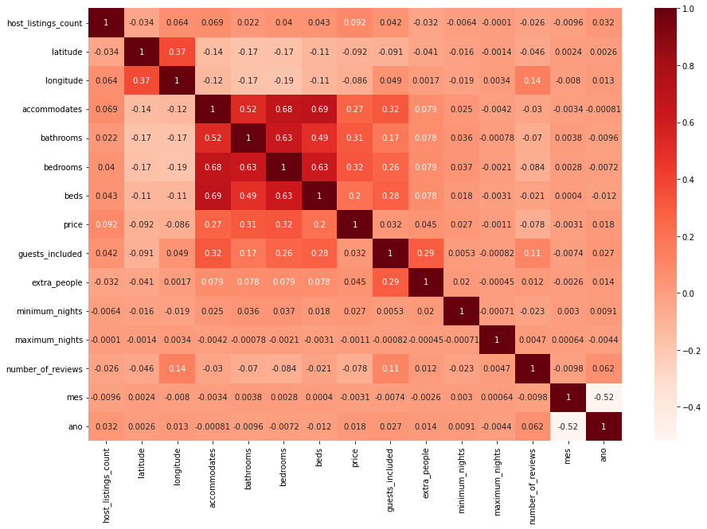

```python
# verificar correlação com um mapa de calor

# print(base_d_dados.corr())
plt.figure(figsize=(15, 10))
sns.heatmap(base_d_dados.corr(), annot=True, cmap='Reds')
```

# Definição de função para analise de outliers

outliers são dados que se diferenciam drasticamente de todos os outros. Em outras palavras, um outlier é um valor que foge da normalidade e que pode (e provavelmente irá) causar anomalias nos resultados obtidos por meio de algoritmos e sistemas de análise

```python
# definir limite para colunas
def limites(coluna):
    q1 = coluna.quantile(0.25)
    q3 = coluna.quantile(0.75)
    amplitude = q3 - q1
    return q1 - 1.5 * amplitude, q3 + 1.5 *amplitude
```

```python
# definir função para diagrama de caixa
def diagrama_cx(coluna):
    fig, (ax1, ax2) = plt.subplots(1, 2)     # configuração do grafico
    fig.set_size_inches(15, 5)              # configuração do grafico
    sns.boxplot(x=coluna, ax=ax1)
    ax2.set_xlim(limites(coluna))
    sns.boxplot(x=coluna, ax=ax2)

# definir função para histrograma
def histrograma(coluna):
    plt.figure(figsize=(15,5))                     # configuração do grafico
    sns.histplot(coluna, bins=50,  kde=True)     # grafico hitrograma

# definir função para excluir outliers
def excluir_outliers(base_d_dados, nome_coluna):
    qtd_linha = base_d_dados.shape[0]
    lim_inf, lim_sup = limites(base_d_dados[nome_coluna])
    base_d_dados = base_d_dados.loc[(base_d_dados[nome_coluna] >= lim_inf) & (base_d_dados[nome_coluna] <= lim_sup), :]
    linhas_removidas = qtd_linha - base_d_dados.shape[0]
    return base_d_dados, linhas_removidas

def grafico_barra(coluna):
    plt.figure(figsize=(15, 5))
    ax = sns.barplot(x=coluna.value_counts().index, y=coluna.value_counts())
    ax.set_xlim(limites(coluna))
```

### Analise de outliers

para analise o objetivo do projeto sera para imóveis comum então sera removidos outliers onde podera atraplhar para analise, como quartos e banheiros em grande quantidade ou alto preço onde seria necessario imóveis de alto padrão

# Price

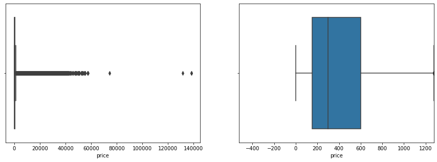

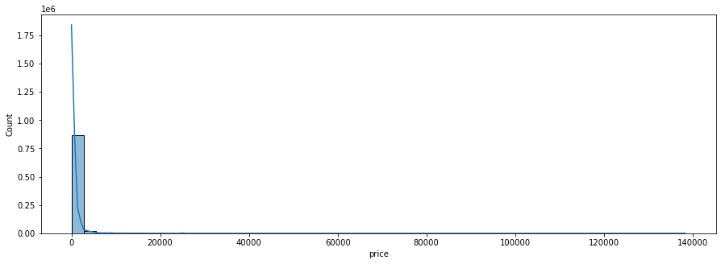

```python
# visualização dos graficos
diagrama_cx(base_d_dados["price"])
histrograma(base_d_dados["price"])
```

```python
base_d_dados, linhas_removida = excluir_outliers(base_d_dados, "price")
print('{} linhas removidas'.format(linhas_removida))
```

```
87282 linhas removidas
```

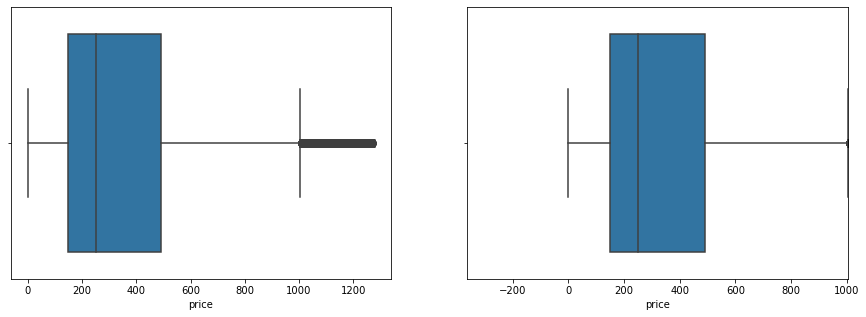

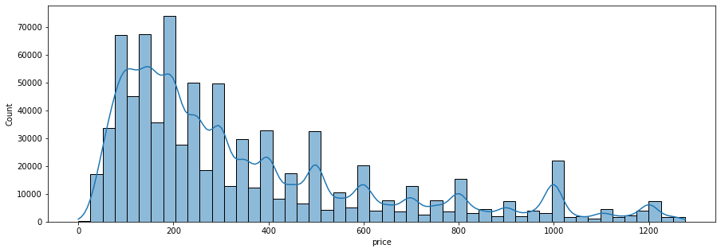

```python
# visualização dos graficos
diagrama_cx(base_d_dados["price"])
histrograma(base_d_dados["price"])
```

### extra_people

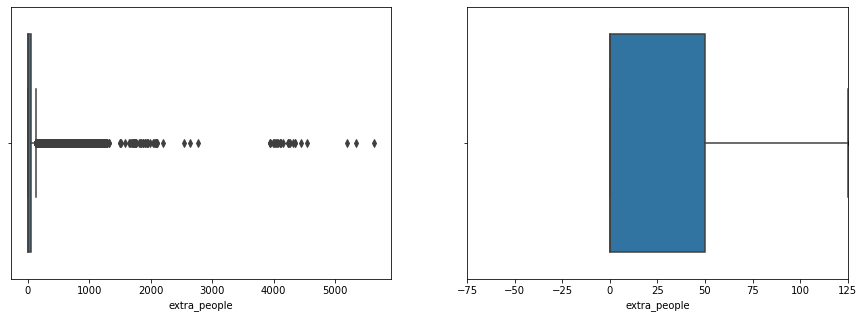

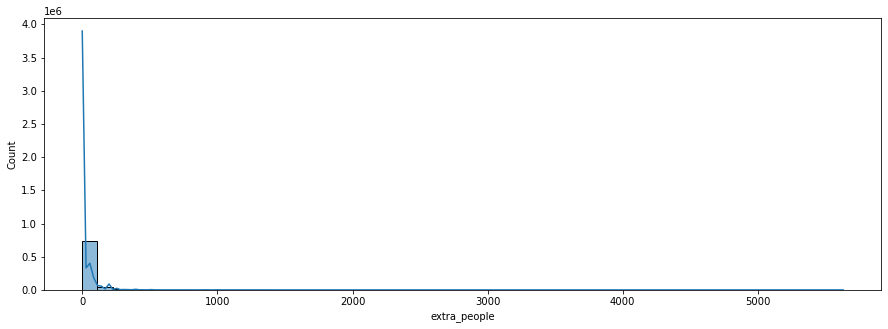

```python
diagrama_cx(base_d_dados['extra_people'])
histrograma(base_d_dados['extra_people'])
```

```python
# Excluindo outliers do extra_people
base_d_dados, linhas_removida = excluir_outliers(base_d_dados, "extra_people")
print('{} linhas removidas'.format(linhas_removida))
```

```
59194 linhas removidas
```

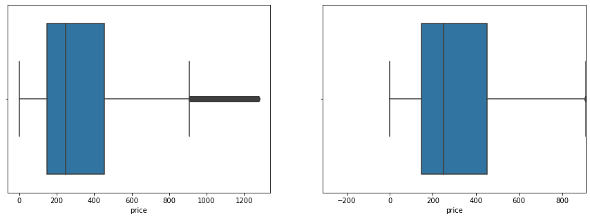

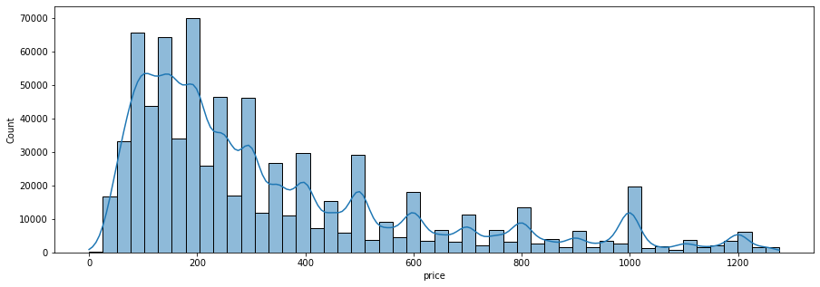

```python
diagrama_cx(base_d_dados["price"])
histrograma(base_d_dados["price"])
```

### host_listings_count

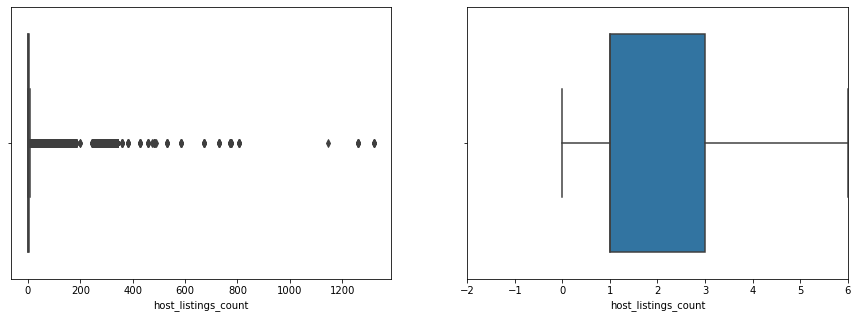

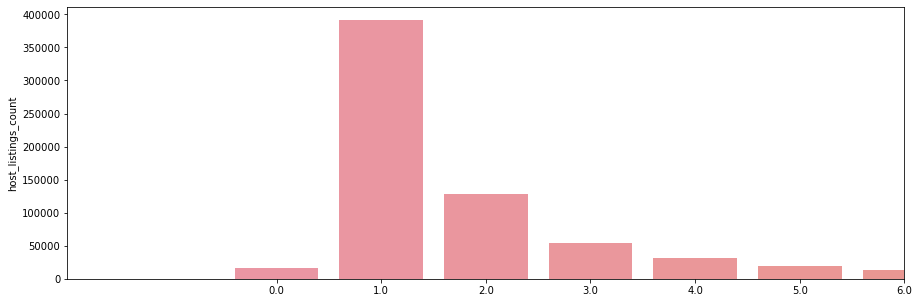

```python
diagrama_cx(base_d_dados["host_listings_count"])
grafico_barra(base_d_dados["host_listings_count"])
```

```python
# Excluindo outliers do host_listings_count
base_d_dados, linhas_removida = excluir_outliers(base_d_dados, "host_listings_count")
print('{} linhas removidas'.format(linhas_removida))
```

```
97723 linhas removidas
```

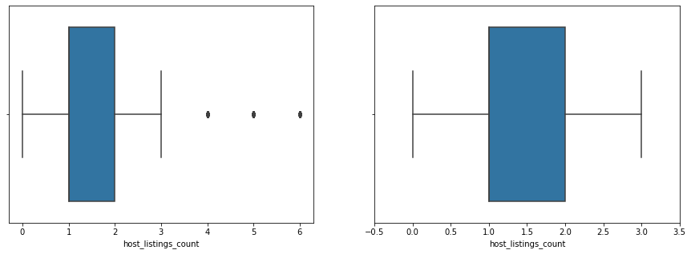

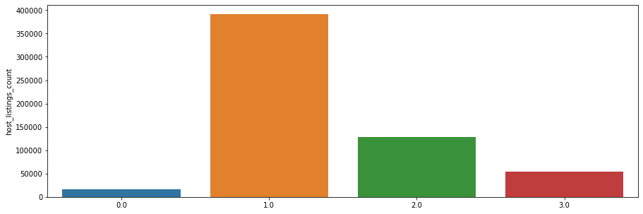

```python
# exbir grafico
diagrama_cx(base_d_dados["host_listings_count"])
grafico_barra(base_d_dados["host_listings_count"])
```

### accommodates

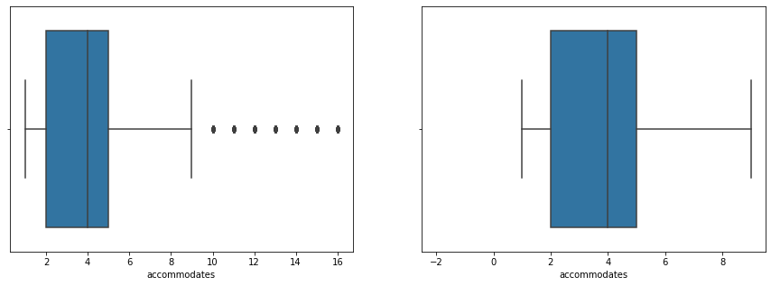

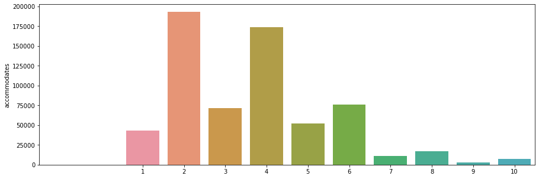

```python
diagrama_cx(base_d_dados["accommodates"])
grafico_barra(base_d_dados["accommodates"])
```

vamos excluir os outliers dessa coluna porque apartamentos que acomodam mais de 9 pessoas nosso objetivo é para imóveis comun

```python
# Excluindo outliers do accommodates
base_d_dados, linhas_removida = excluir_outliers(base_d_dados, "accommodates")
print('{} linhas removidas'.format(linhas_removida))
```

```
13146 linhas removidas
```

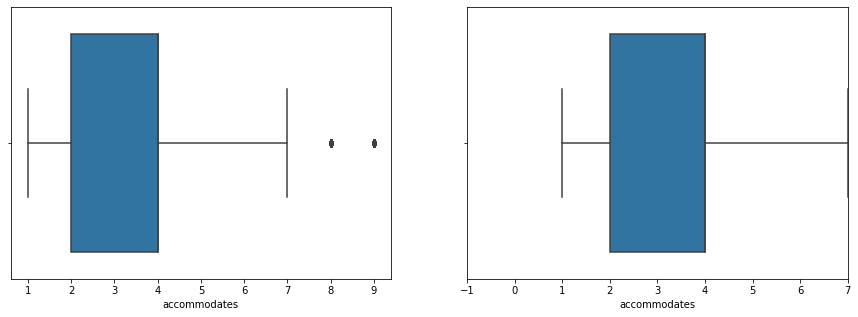

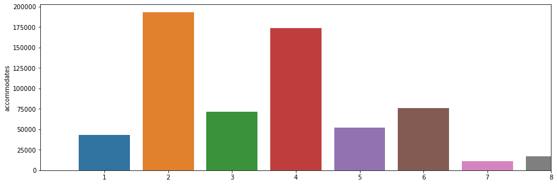

```python
# visualizar grafico
diagrama_cx(base_d_dados["accommodates"])
grafico_barra(base_d_dados["accommodates"])
```

### bathrooms

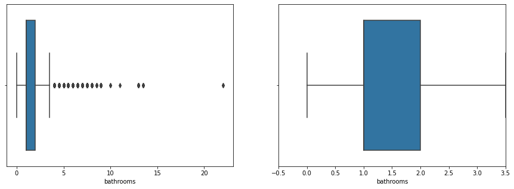

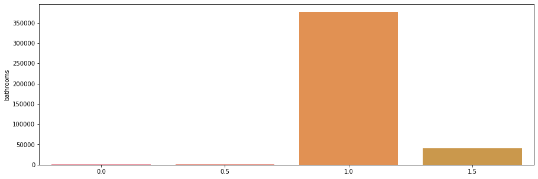

```python
diagrama_cx(base_d_dados["bathrooms"])
grafico_barra(base_d_dados.bathrooms)
```

```python
# Excluindo outliers do bathrooms
base_d_dados, linhas_removida = excluir_outliers(base_d_dados, "bathrooms")
print('{} linhas removidas'.format(linhas_removida))
```

```
6894 linhas removidas
```

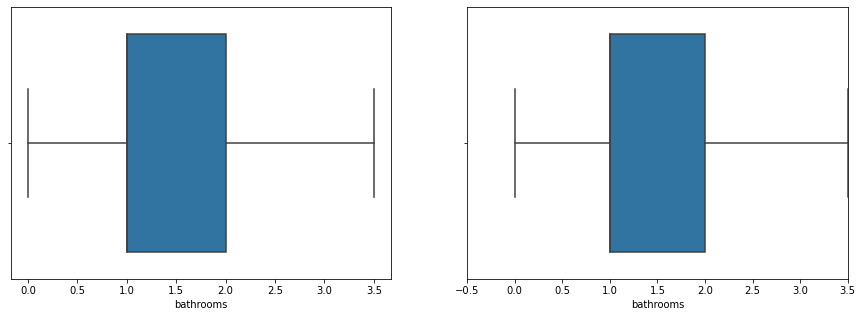

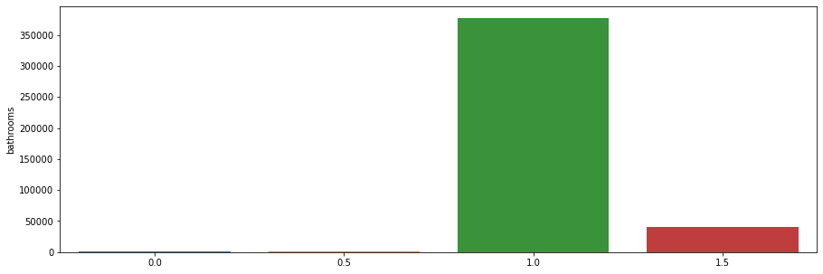

```python
diagrama_cx(base_d_dados.bathrooms)
grafico_barra(base_d_dados.bathrooms)
```

### bedrooms

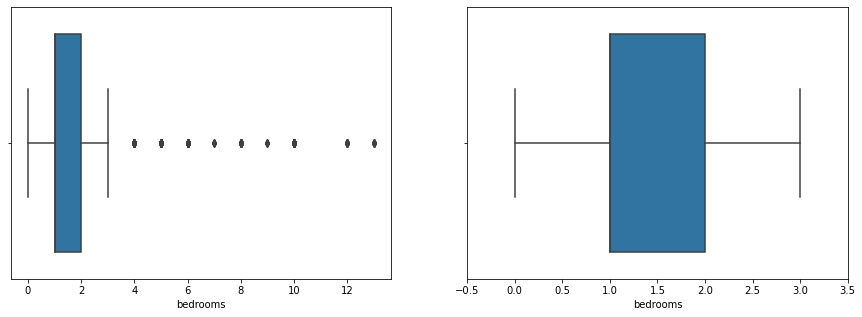

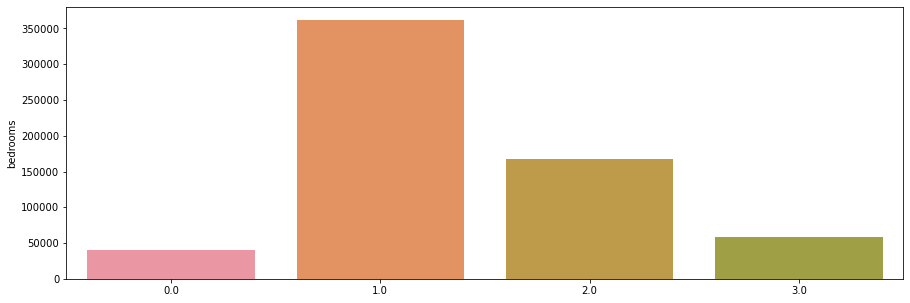

```python
diagrama_cx(base_d_dados.bedrooms)
grafico_barra(base_d_dados.bedrooms)
```

```python
# Excluindo outliers do bedrooms
base_d_dados, linhas_removida = excluir_outliers(base_d_dados, "bedrooms")
print('{} linhas removidas'.format(linhas_removida))
```

```
5482 linhas removidas
```

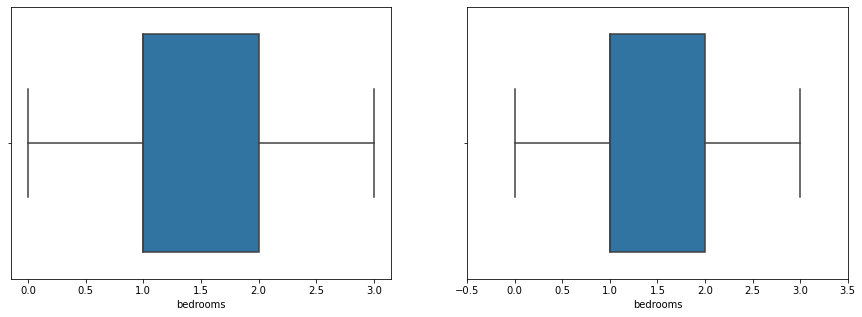

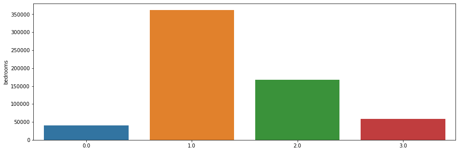

```python
# visualizar graficos
diagrama_cx(base_d_dados["bedrooms"])
grafico_barra(base_d_dados.bedrooms)
```

### beds

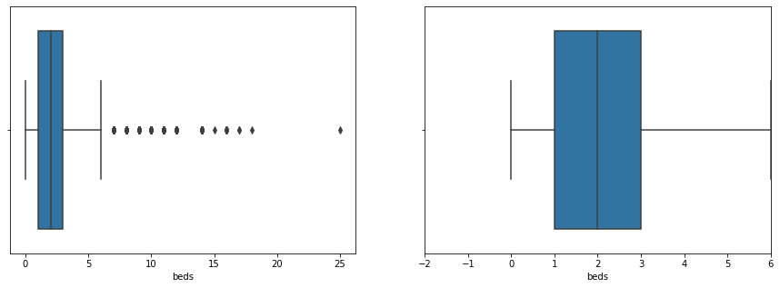

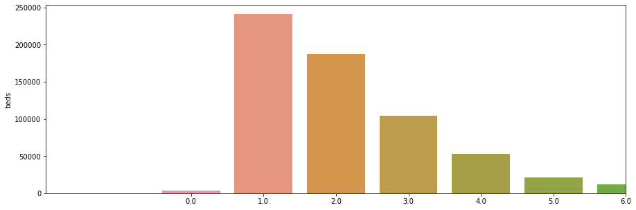

```python
diagrama_cx(base_d_dados["beds"])
grafico_barra(base_d_dados.beds)
```

```python
# Excluindo outliers do beds
base_d_dados, linhas_removida = excluir_outliers(base_d_dados, "beds")
print('{} linhas removidas'.format(linhas_removida))
```

```
5622 linhas removidas
```

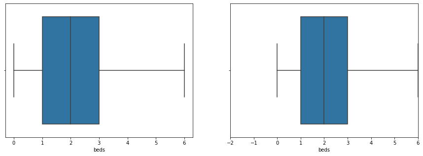

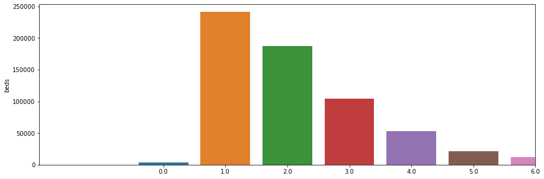

```python
# visualizar graficos
diagrama_cx(base_d_dados["beds"])
grafico_barra(base_d_dados.beds)
```

### guests_included

```
(1.0, 1.0)
```

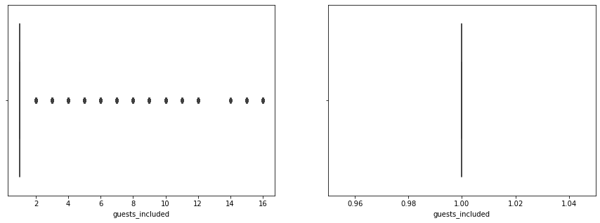

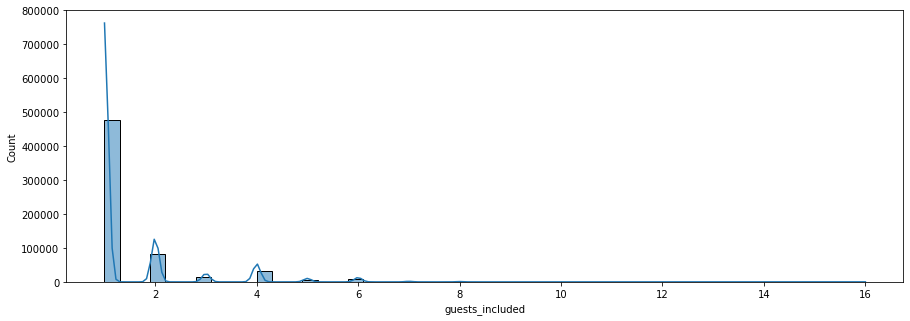

```python
diagrama_cx(base_d_dados.guests_included)
histrograma(base_d_dados.guests_included)
print(limites(base_d_dados.guests_included))
```

Essa feature da análise será removida pois ha hipotese que os usuários do airbnb usam muito o valor padrão do airbnb como 1 guest included. Isso pode levar o nosso modelo a considerar uma feature que na verdade não é essencial para a definição do preço, por isso para não afetar no final do projeto essa featura sera removida

```python
base_d_dados = base_d_dados.drop('guests_included', axis=1)
```